# Chapter code for Applied Predictive Modeling (Kuhn and Johnson, 2013)

Chapter 7

by Brian Hassett

# Chapter 7 Non-Linear Regression Models

This is a `tidymodels` implementation of the code in **Chapter 7** of **Applied Predictive Modeling** by Max Kuhn and Kjell Johnson[^1]. I have already implemented all code and models from this chapter using mainly the `caret` package in a separate notebook, `APM_7.Rmd`. In that notebook I used the `solTrainXtrans` data set as the training data. This data set has already had a transformation applied to it (Box-Cox). In this notebook I have used the full data set (un-transformed) and did the Box-Cox transformation and data splitting myself using the appropriate recipe.

## Setup

```r
# Load packages:
library(AppliedPredictiveModeling)
library(caret)
library(tidyverse)
library(tidymodels)
library(patchwork)

# Load my functions:
source("/home/brian/R/dir/Util/bh_functions.R")

# Options:
theme_set(theme_bw())
options(digits = 4)
```

## Load and Split Data

The `tidymodels` process has its own functions for splitting data. Combine the pre-split training and test data from the `solubility` data into one data frame, then use the `tidymodels` functions to split the data:

```r
# Load data:
data(solubility)

# Combine the data sets (update the name of the outcome vectors to y so that they are the same).
# Also give the data frame a generic name.
df1 <- rbind(
  cbind(y = solTrainY, solTrainX), # training data
  cbind(y = solTestY, solTestX) # test data
)

# Split data:
set.seed(1)
splits <- initial_split(df1) # default prop is 3/4
df_train <- training(splits)
df_test <- testing((splits))

# Create folds for 10-fold cross-validation:
folds <- vfold_cv(df_train, v = 10)
```

## Data Summary

No missing data, and all variables are numeric:

```r
bh_print_data_summary(df1)
```

```
                      [,1]
num_rows              "  1,267"
num_cols              "    229"
num_categorical_cols  "      0"
num_numeric_cols      "    229"
all_missing_cols      "      0"
complete_cols         "    229"
total_missing         "      0"
total_percent_missing "      0"
total_data_points     "290,143"
size_MB               "      1"
```

## Distribution of outcome variable

The outcome variable is not too skewed:

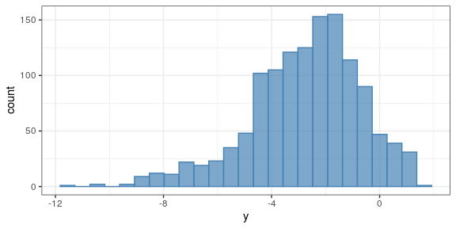

```r
df1 %>%
  ggplot() +
  geom_histogram(aes(y), bins = 25,
                 fill = "steelblue", color = "steelblue", alpha = 0.7)
```

## 7.1 Neural Networks

### Training Data

Build a neural network and train using cross-validation:

```r
# Recipe:
rec1 <-
  recipe(y ~ ., data = df_train) %>%
  step_BoxCox(all_numeric(), -all_outcomes()) %>%
  step_corr(all_predictors(), -all_outcomes(), threshold = 0.75) # same threshold as the `caret` model

# Model:
# I have set the `MaxNWts` argument in the `set_engine()` step. I used the same formula as the `caret` model in `APM_7_1.R`.
# I don't think it matters that I am using the number of columns in `df_train` rather than the number of columns left after
# filtering out correlated variables (as the `caret` model does). As long as the number `MaxNWts` argument is big enough
# it should be fine, and it should be since the number of columns in `df_train` has to be greater than or equal to the
# number of columns in the preprocessed data.
nn_mod <-
  mlp(hidden_units = tune(), penalty = tune(), epochs = 1000) %>% # same number of iterations as the `caret` model
  set_engine("nnet", MaxNWts = 13 * (ncol(df_train) + 1) + 13 + 1) %>%
  set_mode("regression")

# Workflow:
workflow1 <-
  workflow() %>%
  add_model(spec = nn_mod) %>%
  add_recipe(recipe = rec1)

# Create a tuning grid with the same candidate values as the `caret` model (in `APM_7.R`):
nn_grid <- expand.grid(hidden_units = c(1, 3, 5, 7, 9, 11, 13), penalty = c(0, 0.01, 0.1))

# Use `tune::tune_grid()` to combine the workflow and CV folds to fit the model on the training data:
## Read in cached results if available:
file1 <- "/home/brian/R/dir/APM/chapter7/data/nn_cv2.RDS"
if (file.exists(file1)) {
  nn_cv <- readRDS(file1)
} else {
  nn_cv <-
    workflow1 %>%
    tune_grid(resamples = folds,
              grid = nn_grid,
              control = control_grid(save_pred = TRUE),
              metrics = metric_set(rmse, rsq))
  saveRDS(nn_cv, file1)
}
```

Plot CV results:

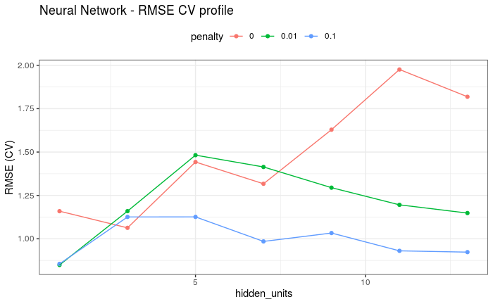

The results are similar to the `caret` workflow and text (Fig. 7.2, page 145).

Select the best model and store the training error:

```r
nn_best <- nn_cv %>%
  select_best("rmse")

# Store the training error:
rmse_train <- nn_cv %>%
  show_best("rmse") %>%
  pluck("mean", 1)
```

### Testing Data

Fit a model using all of the training data and apply it to the test data:

```r
# Finalize the workflow by updating it to use the best model:
final_wf <-
  workflow1 %>%
  finalize_workflow(nn_best)

# This extracts the parameters in the final model (this code is clunky, could probably be made simpler):
wf <- final_wf %>% workflows::pull_workflow_spec()
hidden_units <- wf$args$hidden_units[2] %>% as.character()
```

```
Subsetting quosures with `[` is deprecated as of rlang 0.4.0
Please use `quo_get_expr()` instead.
```

```r
penalty <- wf$args$penalty[2] %>% as.character()

# Fit the final model using all of the training data and evaluate using the test data:
nn_fit_final <-
  final_wf %>%
  last_fit(splits)

# Store test error:
rmse_test <- nn_fit_final %>%
  collect_metrics() %>%
  filter(.metric == "rmse") %>%
  pluck(".estimate")
```

Store the training and test RMSE values and parameters:

```r
RMSE_TM <- tibble(
  framework = "tidymodels",
  engine = "nnet",
  model = "Neural Network",
  rmse_train = rmse_train,
  rmse_test = rmse_test,
  parameters = str_interp("hidden_units: ${hidden_units}; penalty: ${penalty}")
)
```

### Use the predictions to make diagnostic plots

Collect the predictions from the final fit and make diagnostic plots:

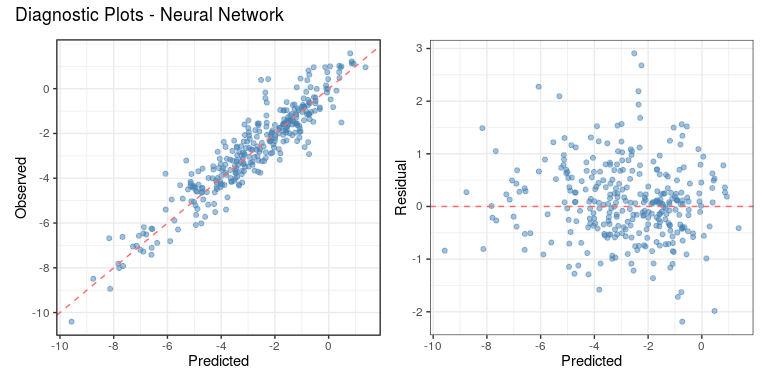

```r
preds <- nn_fit_final %>%
  collect_predictions() %>%
  mutate(residual = y - .pred)

p1 <- ggplot(preds) +
  geom_point(aes(.pred, y),
             color = "steelblue", alpha = 0.5) +
  geom_abline(color = "indianred1", linetype = "dashed") +
  scale_x_continuous("Predicted",
                     breaks = seq(-10, 0, by = 2)) +
  scale_y_continuous("Observed",
                     breaks = seq(-10, 0, by = 2))

p2 <- ggplot(preds) +
  geom_point(aes(.pred, residual),
             color = "steelblue", alpha = 0.5) +
  geom_hline(yintercept = 0,
             color = "indianred1", linetype = "dashed") +
  scale_x_continuous("Predicted",
                     breaks = seq(-10, 0, by = 2)) +
  scale_y_continuous("Residual")

p1 + p2 + plot_annotation(title = "Diagnostic Plots - Neural Network")
```

## 7.2 Multivariate Adaptive Regression Splines (MARS)

### Training Data

Build a MARS model and train using cross-validation: (Run time: 9.07 mins)

```r
# Recipe:
rec2 <-
  recipe(y ~ ., data = df_train) %>%
  step_BoxCox(all_numeric(), -all_outcomes())

# Model:
mars_mod <-
  mars(num_terms = tune(), prod_degree = tune()) %>%
  set_engine("earth") %>%
  set_mode("regression")

# Workflow:
workflow2 <-
  workflow() %>%
  add_model(spec = mars_mod) %>%
  add_recipe(recipe = rec2)

# Create a tuning grid with the same candidate values as the `caret` model (in `APM_7.R`):
mars_grid <- expand.grid(num_terms = 2:38, prod_degree = 1:2)

start <- bh_start_timer()
```

```
[1] "Start time: 2021-03-30 03:12:18"
```

```r
# Use `tune::tune_grid()` to combine the workflow and CV folds to fit the model on the training data:
## Read in cached results if available:
file1 <- "/home/brian/R/dir/APM/chapter7/data/mars_cv.RDS"
if (file.exists(file1)) {
  mars_cv <- readRDS(file1)
} else {
  mars_cv <-
    workflow1 %>%
    tune_grid(resamples = folds,
              grid = mars_grid,
              control = control_grid(save_pred = TRUE),
              metrics = metric_set(rmse, rsq))
  saveRDS(mars_cv, file1)
}

end <- bh_end_timer()
```

```
[1] "End time: 2021-03-30 03:12:18"
```

```r
bh_run_time(start, end)
```

```
[1] "Run time: 0.18 secs"
```

Plot CV results:

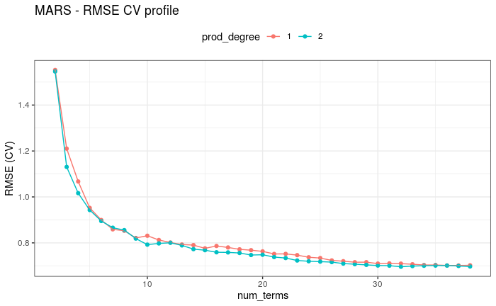

```r
mars_cv %>%
  collect_metrics() %>%
  filter(.metric == "rmse") %>%
  mutate(prod_degree = factor(prod_degree)) %>%
  ggplot(aes(num_terms, mean, color = prod_degree)) +
  geom_point() +
  geom_line() +
  labs(y = "RMSE (CV)", title = "MARS - RMSE CV profile") +
  theme(legend.position = "top")
```

The results are similar to the `caret` workflow and text (Fig 7.4, page 150).

Select the best model and store the training error:

```r
mars_best <- mars_cv %>%
  select_best("rmse")

# Store the training error:
rmse_train <- mars_cv %>%
  show_best("rmse") %>%
  pluck("mean", 1)
```

### Testing Data

Fit a model using all of the training data and apply it to the test data:

```r
# Finalize the workflow by updating it to use the best model:
final_wf <-
  workflow2 %>%
  finalize_workflow(mars_best)

# This extracts the parameters in the final model (this code is clunky, could probably be made simpler):
wf <- final_wf %>% workflows::pull_workflow_spec()
num_terms <- wf$args$num_terms[2] %>% as.character()
prod_degree <- wf$args$prod_degree[2] %>% as.character()

# Fit the final model using all of the training data and evaluate using the test data:
mars_fit_final <-
  final_wf %>%
  last_fit(splits)

# Store test error:
rmse_test <- mars_fit_final %>%
  collect_metrics() %>%
  filter(.metric == "rmse") %>%
  pluck(".estimate")
```

Store the training and test RMSE values and parameters:

```r
RMSE_TM <- rbind(RMSE_TM,
                 c(framework = "tidymodels",
                   engine = "earth",
                   model = "MARS",
                   rmse_train = rmse_train,
                   rmse_test = rmse_test,
                   parameters = str_interp("num_terms: ${num_terms}; prod_degree: ${prod_degree}")))
```

### Use the predictions to make diagnostic plots

Collect the predictions from the final fit and make diagnostic plots:

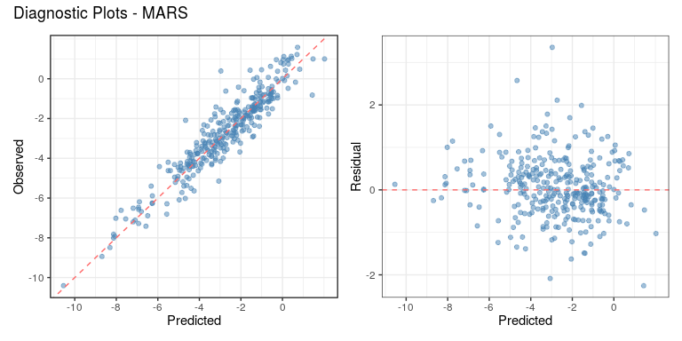

```r
preds <- mars_fit_final %>%
  collect_predictions() %>%
  mutate(residual = y - .pred)

p1 <- ggplot(preds) +
  geom_point(aes(.pred, y),
             color = "steelblue", alpha = 0.5) +
  geom_abline(color = "indianred1", linetype = "dashed") +
  scale_x_continuous("Predicted",
                     breaks = seq(-10, 0, by = 2)) +
  scale_y_continuous("Observed",
                     breaks = seq(-10, 0, by = 2))

p2 <- ggplot(preds) +
  geom_point(aes(.pred, residual),
             color = "steelblue", alpha = 0.5) +
  geom_hline(yintercept = 0,
             color = "indianred1", linetype = "dashed") +
  scale_x_continuous("Predicted",
                     breaks = seq(-10, 0, by = 2)) +
  scale_y_continuous("Residual")

p1 + p2 + plot_annotation(title = "Diagnostic Plots - MARS")
```

## 7.3 Support Vector Machines

### SVM with Radial Basis Function Kernel

### Training Data

Build an SVM RBF kernel model and train using cross-validation: (Run time: 8.51 mins)

```r
# Recipe:
rec3 <-
  recipe(y ~ ., data = df_train) %>%
  step_BoxCox(all_numeric(), -all_outcomes()) %>%
  step_center(all_predictors()) %>%
  step_scale(all_predictors())

# Model:
svm_rbf_mod <-
  svm_rbf(cost = tune()) %>% # leave `sigma` (varies) and `margin` (0.1) as the default
  set_engine("kernlab") %>%
  set_mode("regression")

# Workflow:
workflow3.1 <-
  workflow() %>%
  add_model(spec = svm_rbf_mod) %>%
  add_recipe(recipe = rec3)

# Create a tuning grid with the same candidate values as the `caret` model (in `APM_7.R`):
svm_rbf_grid <- expand.grid(cost = 2^(-2:11))

start <- bh_start_timer()
```

```
[1] "Start time: 2021-03-30 03:12:28"
```

```r
# Use `tune::tune_grid()` to combine the workflow and CV folds to fit the model on the training data:
## Read in cached results if available:
file1 <- "/home/brian/R/dir/APM/chapter7/data/svm_rbf_cv.RDS"
if (file.exists(file1)) {
  svm_rbf_cv <- readRDS(file1)
} else {
  svm_rbf_cv <-
    workflow3.1 %>%
    tune_grid(resamples = folds,
              grid = svm_rbf_grid,
              control = control_grid(save_pred = TRUE),
              metrics = metric_set(rmse, rsq))
  saveRDS(svm_rbf_cv, file1)
}

end <- bh_end_timer()
```

```
[1] "End time: 2021-03-30 03:12:28"
```

```r
bh_run_time(start, end)
```

```
[1] "Run time: 0.16 secs"
```

Plot CV results:

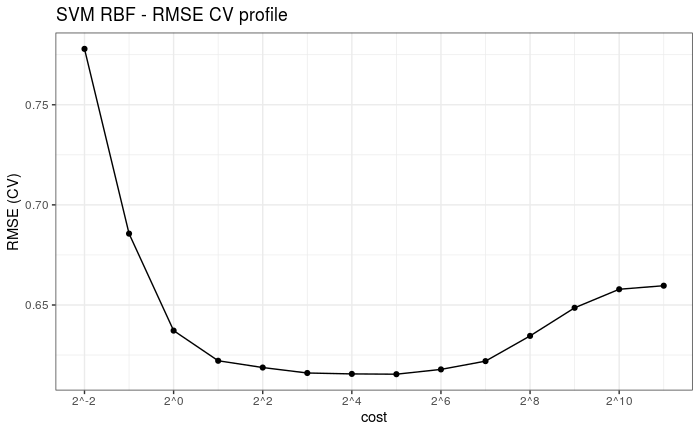

```r
svm_rbf_cv %>%
  collect_metrics() %>%
  filter(.metric == "rmse") %>%
  ggplot(aes(cost, mean)) +
  geom_point() +
  geom_line() +
  scale_x_continuous(trans = "log2",
                     breaks = 2^seq(-2, 11, by = 2),
                     labels = str_c("2^",seq(-2, 11, by = 2))) +
  labs(y = "RMSE (CV)", title = "SVM RBF - RMSE CV profile") +
  theme(legend.position = "top")
```

The results are similar to the `caret` workflow and text (Fig 7.8, page 158).

Select the best model and store the training error:

```r
svm_rbf_best <- svm_rbf_cv %>%
  select_best("rmse")

# Store the training error:
rmse_train <- svm_rbf_cv %>%
  show_best("rmse") %>%
  pluck("mean", 1)
```

### Testing Data

Fit a model using all of the training data and apply it to the test data:

```r
# Finalize the workflow by updating it to use the best model:
final_wf <-
  workflow3.1 %>%
  finalize_workflow(svm_rbf_best)

# This extracts the parameters in the final model (this code is clunky, could probably be made simpler):
wf <- final_wf %>% workflows::pull_workflow_spec()
cost <- wf$args$cost[2] %>% as.character()

# Fit the final model using all of the training data and evaluate using the test data:
svm_rbf_fit_final <-
  final_wf %>%
  last_fit(splits)

# Store test error:
rmse_test <- svm_rbf_fit_final %>%
  collect_metrics() %>%
  filter(.metric == "rmse") %>%
  pluck(".estimate")
```

Store the training and test RMSE values and parameters:

```r
RMSE_TM <- rbind(RMSE_TM,
                 c(framework = "tidymodels",
                   engine = "kernlab",
                   model = "SVM (Radial Basis)",
                   rmse_train = rmse_train,
                   rmse_test = rmse_test,
                   parameters = str_interp("cost: ${cost}")))
```

### Use the predictions to make diagnostic plots

Collect the predictions from the final fit and make diagnostic plots:

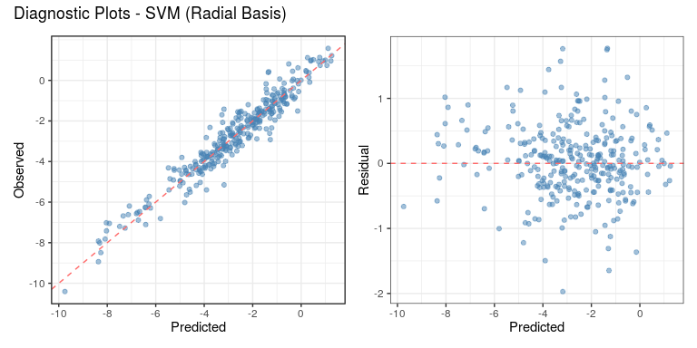

```r
preds <- svm_rbf_fit_final %>%
  collect_predictions() %>%
  mutate(residual = y - .pred)

p1 <- ggplot(preds) +
  geom_point(aes(.pred, y),
             color = "steelblue", alpha = 0.5) +
  geom_abline(color = "indianred1", linetype = "dashed") +
  scale_x_continuous("Predicted",
                     breaks = seq(-10, 0, by = 2)) +
  scale_y_continuous("Observed",
                     breaks = seq(-10, 0, by = 2))

p2 <- ggplot(preds) +
  geom_point(aes(.pred, residual),
             color = "steelblue", alpha = 0.5) +
  geom_hline(yintercept = 0,
             color = "indianred1", linetype = "dashed") +
  scale_x_continuous("Predicted",
                     breaks = seq(-10, 0, by = 2)) +
  scale_y_continuous("Residual")

p1 + p2 + plot_annotation(title = "Diagnostic Plots - SVM (Radial Basis)")
```

### SVM with Polynomial Kernel

### Training Data

Build an SVM polynomial kernel model and train using cross-validation:

```r
# Model:
svm_poly_mod <-
  svm_poly(cost = tune(), degree = tune(), scale_factor = tune()) %>% # leave `margin` (0.1) as the default
  set_engine("kernlab") %>%
  set_mode("regression")

# Workflow:
workflow3.2 <-
  workflow() %>%
  add_model(spec = svm_poly_mod) %>%
  add_recipe(recipe = rec3)

# Create a tuning grid with the same candidate values as the `caret` model (in `APM_7.R`):
svm_poly_grid <- expand.grid(degree = 1:2,
                            scale_factor = c(0.01, 0.005, 0.001),
                            cost = 2^(-2:5))

# Use `tune::tune_grid()` to combine the workflow and CV folds to fit the model on the training data:
## Read in cached results if available:
file1 <- "/home/brian/R/dir/APM/chapter7/data/svm_poly_cv.RDS"
if (file.exists(file1)) {
  svm_poly_cv <- readRDS(file1)
} else {
  svm_poly_cv <-
    workflow3.2 %>%
    tune_grid(resamples = folds,
              grid = svm_poly_grid,
              control = control_grid(save_pred = TRUE),
              metrics = metric_set(rmse, rsq))
  saveRDS(svm_poly_cv, file1)
}
```

Plot CV results:

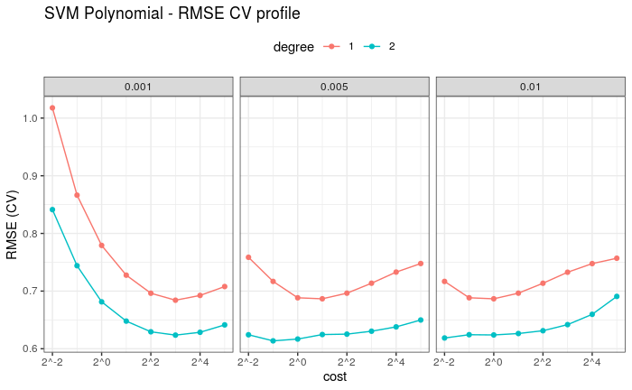

```r
svm_poly_cv %>%
  collect_metrics() %>%
  filter(.metric == "rmse") %>%
  mutate(scale_factor = factor(scale_factor),
         degree = factor(degree)) %>%
  ggplot(aes(cost, mean, group = degree, color = degree)) +
  geom_point() +
  geom_line() +
  # geom_errorbar(aes(ymin = mean - 2*std_err, ymax = mean + 2*std_err),
  #                 color = "indianred1") +
  scale_x_continuous(trans = "log2",
                     breaks = 2^seq(-2, 5, by = 2),
                     labels = str_c("2^",seq(-2, 5, by = 2))) +
  facet_wrap(~scale_factor) +
  labs(y = "RMSE (CV)", title = "SVM Polynomial - RMSE CV profile") +
  theme(legend.position = "top")
```

The results are similar to the `caret` workflow and text (Fig 7.9, page 158).

Select the best model and store the training error:

```r
svm_poly_best <- svm_poly_cv %>%
  select_best("rmse")

# Store the training error:
rmse_train <- svm_poly_cv %>%
  show_best("rmse") %>%
  pluck("mean", 1)
```

### Testing Data

Fit a model using all of the training data and apply it to the test data:

```r
# Finalize the workflow by updating it to use the best model:
final_wf <-
  workflow3.2 %>%
  finalize_workflow(svm_poly_best)

# This extracts the parameters in the final model (this code is clunky, could probably be made simpler):
wf <- final_wf %>% workflows::pull_workflow_spec()
cost <- wf$args$cost[2] %>% as.character()
degree <- wf$args$degree[2] %>% as.character()
scale_factor <- wf$args$scale_factor[2] %>% as.character()

# Fit the final model using all of the training data and evaluate using the test data:
svm_poly_fit_final <-
  final_wf %>%
  last_fit(splits)

# Store test error:
rmse_test <- svm_poly_fit_final %>%
  collect_metrics() %>%
  filter(.metric == "rmse") %>%
  pluck(".estimate")
```

Store the training and test RMSE values and parameters:

```r
RMSE_TM <- rbind(RMSE_TM,
                 c(framework = "tidymodels",
                   engine = "kernlab",
                   model = "SVM (Polynomial)",
                   rmse_train = rmse_train,
                   rmse_test = rmse_test,
                   parameters = str_interp("cost: ${cost}; degree: ${degree}; scale_factor: ${scale_factor}")))
```

### Use the predictions to make diagnostic plots

Collect the predictions from the final fit and make diagnostic plots:

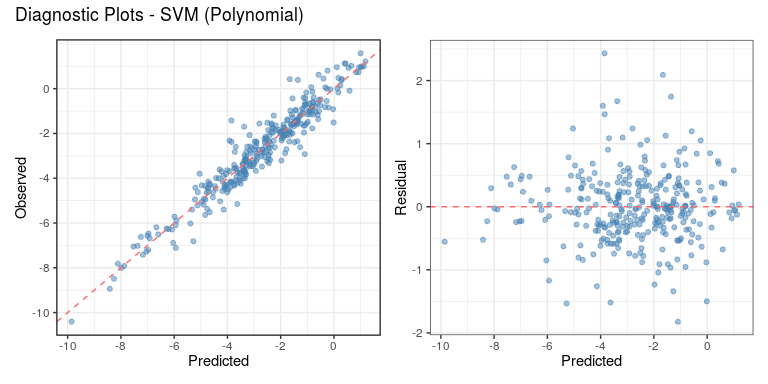

```r
preds <- svm_poly_fit_final %>%
  collect_predictions() %>%
  mutate(residual = y - .pred)

p1 <- ggplot(preds) +
  geom_point(aes(.pred, y),
             color = "steelblue", alpha = 0.5) +
  geom_abline(color = "indianred1", linetype = "dashed") +
  scale_x_continuous("Predicted",
                     breaks = seq(-10, 0, by = 2)) +
  scale_y_continuous("Observed",
                     breaks = seq(-10, 0, by = 2))

p2 <- ggplot(preds) +
  geom_point(aes(.pred, residual),
             color = "steelblue", alpha = 0.5) +
  geom_hline(yintercept = 0,
             color = "indianred1", linetype = "dashed") +
  scale_x_continuous("Predicted",
                     breaks = seq(-10, 0, by = 2)) +
  scale_y_continuous("Residual")

p1 + p2 + plot_annotation(title = "Diagnostic Plots - SVM (Polynomial)")
```

## 7.4 K-Nearest Neighbors

### Training Data

Build a KNN model and train using cross-validation: (Run time: 2 mins)

```r
# Recipe:
rec4 <-
  recipe(y ~ ., data = df_train) %>%
  step_BoxCox(all_numeric(), -all_outcomes()) %>%
  step_nzv(all_predictors()) %>%
  step_center(all_predictors()) %>%
  step_scale(all_predictors())

# Model:
knn_mod <-
  nearest_neighbor(neighbors = tune()) %>%
  set_engine("kknn") %>%
  set_mode("regression")

# Workflow:
workflow4 <-
  workflow() %>%
  add_model(spec = knn_mod) %>%
  add_recipe(recipe = rec4)

# Create a tuning grid with the same candidate values as the `caret` model (in `APM_7.R`):
knn_grid <- tibble(neighbors = 1:20)

# Use `tune::tune_grid()` to combine the workflow and CV folds to fit the model on the training data:
## Read in cached results if available:
file1 <- "/home/brian/R/dir/APM/chapter7/data/knn_cv.RDS"
if (file.exists(file1)) {
  knn_cv <- readRDS(file1)
} else {
  knn_cv <-
    workflow4 %>%
    tune_grid(resamples = folds,
              grid = knn_grid,
              control = control_grid(save_pred = TRUE),
              metrics = metric_set(rmse, rsq))
  saveRDS(knn_cv, file1)
}
```

Plot CV results:

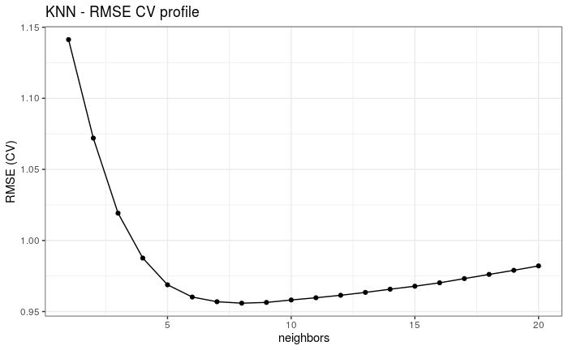

```r
knn_cv %>%
  collect_metrics() %>%
  filter(.metric == "rmse") %>%
  ggplot(aes(neighbors, mean)) +
  geom_point() +
  geom_line() +
  labs(y = "RMSE (CV)", title = "KNN - RMSE CV profile")
```

The results are similar to the `caret` workflow and text (Fig 7.10, page 161).

Select the best model and store the training error:

```r
knn_best <- knn_cv %>%
  select_best("rmse")

# Store the training error:
rmse_train <- knn_cv %>%
  show_best("rmse") %>%
  pluck("mean", 1)
```

### Testing Data

Fit a model using all of the training data and apply it to the test data:

```r
# Finalize the workflow by updating it to use the best model:
final_wf <-
  workflow4 %>%
  finalize_workflow(knn_best)

# This extracts the parameters in the final model (this code is clunky, could probably be made simpler):
wf <- final_wf %>% workflows::pull_workflow_spec()
neighbors <- wf$args$neighbors[2] %>% as.character()

# Fit the final model using all of the training data and evaluate using the test data:
knn_fit_final <-
  final_wf %>%
  last_fit(splits)

# Store test error:
rmse_test <- knn_fit_final %>%
  collect_metrics() %>%
  filter(.metric == "rmse") %>%
  pluck(".estimate")
```

Store the training and test RMSE values and parameters:

```r
RMSE_TM <- rbind(RMSE_TM,
                 c(framework = "tidymodels",
                   engine = "kknn",
                   model = "KNN",
                   rmse_train = rmse_train,
                   rmse_test = rmse_test,
                   parameters = str_interp("neighbors: ${neighbors}")))
```

### Use the predictions to make diagnostic plots

Collect the predictions from the final fit and make diagnostic plots:

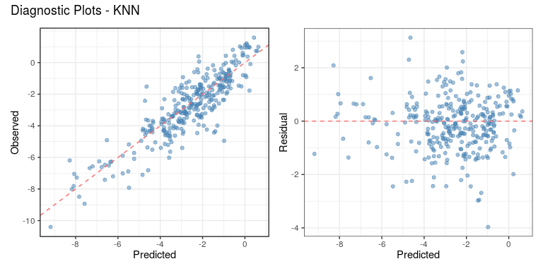

```r
preds <- knn_fit_final %>%
  collect_predictions() %>%
  mutate(residual = y - .pred)

p1 <- ggplot(preds) +
  geom_point(aes(.pred, y),
             color = "steelblue", alpha = 0.5) +
  geom_abline(color = "indianred1", linetype = "dashed") +
  scale_x_continuous("Predicted",
                     breaks = seq(-10, 0, by = 2)) +
  scale_y_continuous("Observed",
                     breaks = seq(-10, 0, by = 2))

p2 <- ggplot(preds) +
  geom_point(aes(.pred, residual),
             color = "steelblue", alpha = 0.5) +
  geom_hline(yintercept = 0,
             color = "indianred1", linetype = "dashed") +
  scale_x_continuous("Predicted",
                     breaks = seq(-10, 0, by = 2)) +
  scale_y_continuous("Residual")

p1 + p2 + plot_annotation(title = "Diagnostic Plots - KNN")
```

## Metrics

Metrics from this notebook:

```r
RMSE_TM %>%
  mutate(rmse_train = as.numeric(rmse_train),
         rmse_test = as.numeric(rmse_test)) %>%
  arrange(rmse_test)
```

| framework | engine | model | rmse_train | rmse_test | parameters |
| --- | --- | --- | --- | --- | --- |
| tidymodels | kernlab | SVM (Radial Basis) | 0.6154 | 0.5523 | cost: 32 |
| tidymodels | kernlab | SVM (Polynomial) | 0.6137 | 0.5580 | cost: 0.5; degree: 2; scale_factor: 0.005 |
| tidymodels | earth | MARS | 0.6961 | 0.7118 | num_terms: 32; prod_degree: 2 |
| tidymodels | nnet | Neural Network | 0.8490 | 0.7378 | hidden_units: 1; penalty: 0.01 |
| tidymodels | kknn | KNN | 0.9559 | 0.9873 | neighbors: 8 |

Compare to metrics from the `caret` notebook:

```r
RMSE_caret <- readRDS("/home/brian/R/dir/APM/chapter7/data/RMSE_caret_APM_7.RDS")
RMSE_caret %>%
  mutate(rmse_train = as.numeric(rmse_train),
         rmse_test = as.numeric(rmse_test)) %>%
  arrange(rmse_test)
```

| framework | engine | model | rmse_train | rmse_test | parameters |
| --- | --- | --- | --- | --- | --- |
| caret | kernlab | SVM (Polynomial) | 0.6147 | 0.6040 | degree: 2; scale: 0.01; C: 2 |
| caret | kernlab | SVM (Radial Basis) | 0.5957 | 0.6073 | sigma: 0.002655; C: 256 |
| caret | earth | MARS | 0.6772 | 0.7312 | nprune: 36; degree: 1 |
| caret | avNNet | Neural Network | 0.8059 | 0.8007 | size: 1; decay: 0.01 |
| caret | class | KNN | 1.0295 | 1.0783 | k: 5 |

[^1]: Kuhn M, Johnson K (2013). *Applied Predictive Modeling*. Springer.